# Edit Distance and Approximate String Matching

Jared Berry

February 18, 2019

In the era of spell check and autocorrect, it’s probably a fair assumption that anyone reading this has had a misspelled or mistyped word corrected for them, or has been presented with a menu of options for what the word *might* have been. Suppose, however, one needed to implement something like this in a data product. For instance, beyond the clear use case of predictive text and autocorrect, the same approach can be leveraged for ‘fuzzy’ merges. In the absence of defined keys to merge two data sets, suppose you have two columns of names to match on. We can pre-process the text to the best of our ability (applying some of the techniques in the previous post), but there are bound to be discrepancies that can’t be addressed directly with pre-processing. To build something equivalent from scratch, we can use a *distance* measure.

In this post, I’ll focus on *edit distance*, for a few reasons. First and foremost, we can implement the edit distance algorithm from scratch, by applying dynamic programming, to appreciate and understand how it works “under-the-hood”. Second (and also the primary reason I’m using R here), base R has an edit distance function ready to go, off the shelf, that could be used to handle the use case described above.

## The problem

Given two strings $s$ and $t$ of length $\ge 1$, the edit distance between strings $s$ and $t$ is defined as the number of *insertions*, *deletions*, and *substitutions* needed such that $s=t$. As it is typically postulated, we suppose each of these transformations have *unit cost*, i.e. each insertion, deletion, or substitution adds 1 to the cost of performing the overall transformation. In our implementation, and in the base R function, we can also adapt these costs to fit our particular use case.

Let’s take two words, `"boats"` and `"floats"`, as an example. What steps (insertions, deletions, and substitions) are necessary to tranform `"boats"` into `"afloat"`

`BOATS`  
`AFLOAT`

`AOATS <- Substitute 'A' for 'B'`  
`AFLOAT`

`AFOATS <- Insert 'F'`  
`AFLOAT`

`AFLOATS <- Insert 'L'`  
`AFLOAT`

`AFLOAT <- Delete 'S'`  
`AFLOAT`

Working through this by hand, we find it takes at least 4 tranformations to transform `"boats"` into `"floats"`. We can implement these transformations algorithmically with an implementation of the Levenshtein algorithm. Using a dynamic programming matrix (credited to Wagner-Fischer) `D` and strings $s$ and $t$ of lengths $m$ and $n$, we have:

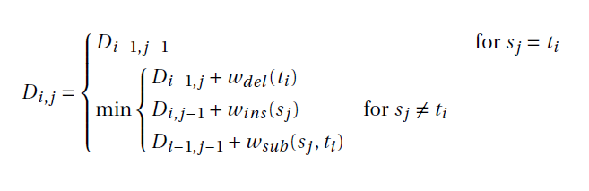

As hinted at, we’ll leverage dynamic programming in our implentation of edit distance.

## The algorithm

The hallmark of dynamic programming is that it breaks large, potentially intractable problems into smaller, more managable subparts. In our implementation, we use a dynamic programming matrix `D` which stores the results of the formula above for each substring $i$ and $j$ this also has the useful property of cumulating the costs of each transformation as we iterate through each string.

By storing the costs at each iteration, we greatly reduce the complexity of our problem, particularly as the lengths of strings $s$ and $t$ increase. In fact, we only need to compute the cost for each combination of the substrings of $s$ and $t$ *once*, rather than computing the costs repeatedly in each recursive call *without* dynamic programming.

```r
edit_distance <- function(s, t) {
  m = nchar(s) + 1
  n = nchar(t) + 1
  D = matrix(0, nrow = m, ncol = n)

  for(i in 0:nchar(s)) {
    D[i+1,1] <- i
  }

  for(j in 1:nchar(t)) {
    D[1,j+1] <- j
  }

  for(j in 2:n) {
    for(i in 2:m) {
      insert = D[i,j-1] + 1
      delete = D[i-1, j] + 1
      matched = D[i-1,j-1]
      mismatched = D[i-1,j-1] + 1

      if(substr(s, i-1, i-1) == substr(t, j-1, j-1)) {
        D[i,j] = min(insert, delete, matched)
      } else {
        D[i,j] = min(insert, delete, mismatched)
      }

    }
  }

  return(D[m-1,n-1])

}
```

We begin my instantiating a matrix $D$ with $m$ rows and $n$ columns based on the length of the two strings $s$ and $t$, plus 1. In the first row and first column, we simply enumerate the length of the string. So, for the strings `"boats"` and `"afloat"`, we have:

```
##      [,1] [,2] [,3] [,4] [,5] [,6] [,7]
## [1,]    0    1    2    3    4    5    6
## [2,]    1    0    0    0    0    0    0
## [3,]    2    0    0    0    0    0    0
## [4,]    3    0    0    0    0    0    0
## [5,]    4    0    0    0    0    0    0
## [6,]    5    0    0    0    0    0    0
```

This matrix represents the costs we need to calculate to determine the total edit distance between the two strings. As indicated above, this amounts to only $m*n$ iterations, where $m$ and $n$ are the lengths of the two strings. We begin iterating over the characters of strings $s$ and $t$, compute costs according to the formula prescribed above, and store the results. Walking through one iteration, we have the following:

```
## Insert: 2
```

```
## Delete: 2
```

```
## Matched: 0
```

```
## Mismatched: 1
```

```
##      [,1] [,2] [,3] [,4] [,5] [,6] [,7]
## [1,]    0    1    2    3    4    5    6
## [2,]    1    1    0    0    0    0    0
## [3,]    2    0    0    0    0    0    0
## [4,]    3    0    0    0    0    0    0
## [5,]    4    0    0    0    0    0    0
## [6,]    5    0    0    0    0    0    0
```

As the first characters of $s$ and $t$ do not match, we choose the operation with the minimum cost (`mismatched`, or proxy for a substitution) and store the cost in the dynamic programming matrix $D$. The formula we’ve implemented here has the desirable property of traversing through the rest of the combinations of the characters in $s$ and $t$, storing all possible transformations, and selecting the set of transformations with the *minimum total cost*. While the cost of this initial mismatch propogates through the entire transformation, we choose the path which minimizes the subsequent costs. We end up with the final, fully populated, dynamic programming matrix:

```
##      [,1] [,2] [,3] [,4] [,5] [,6] [,7]
## [1,]    0    1    2    3    4    5    6
## [2,]    1    1    2    3    4    5    6
## [3,]    2    2    2    3    3    4    5
## [4,]    3    2    3    3    4    3    4
## [5,]    4    3    3    4    4    4    3
## [6,]    5    4    4    4    5    5    4
```

The value at $D[m,n]$ is the edit distance between the two strings, and represents the minimum cost of performing the transformations necessary for $s$ to exactly match $t$. So, the edit distance between `"boats"` and `"afloat"` is 4, just as we surmised above.

```r
edit_distance("boats", "afloat")
```

```
## [1] 4
```

## Edit distance off-the-shelf – `adist`

The reason I’ve used R here (rather than, say, Python where strings are iterables) is to demonstrate how the edit distance algorithm works “under-the-hood” before introducing two built in functions that will perform the same operation. The R function `adist` will compute the edit distance between two strings `x` and `y` just as above:

```r
adist("boats", "afloat")
```

```
##      [,1]
## [1,]    4
```

Moreover, we can pass *vectors* of strings to evaluate all the distances across both vectors:

```r
adist(c("boats", "canoes"), c("afloat", "canoodle"))
```

```
##      [,1] [,2]
## [1,]    4    7
## [2,]    5    4
```

And, if we are uninterest in the off-diagonal distances (i.e. we want to find the edit distance between `"boats"` and `"afloat"` and `"canoes"` and `"canoodle"` but *not* between `"boats"` and `"canoodle"`) we can simply return the diagonal of the resulting matrix.

```r
diag(adist(c("boats", "canoes"), c("afloat", "canoodle")))
```

```
## [1] 4 4
```

So, given two columns of names/strings for possible join, we can use this in conjunction with the `dplyr` mutate function to create a `distance` column, like `mutate(data, distance = diag(adist(str_column_1, str_column_2)))`.

As an example, take the two following dataframes of identifying variables from the FFIEC 031/041 (Call report) and the Small Business Association:

```
##   rssd_id                                                            name
## 1  130635                             FIRST COMMERCIAL BANK OF HUNTSVILLE
## 2  154154 FIRST NATIONAL BANK AND TRUST COMPANY, CHICKASHA, OKLAHOMA, THE
## 3  155517                                        GREAT LAKES BANKERS BANK
## 4  255136                                                   FRONTIER BANK
## 5  327958             OKLAHOMA NATIONAL BANK & TRUST COMPANY OF CHICKASHA
## 6  328450                                  CHICKASHA BANK & TRUST COMPANY
##          city   zip state
## 1  HUNTSVILLE 35801    AL
## 2   CHICKASHA 73018    OK
## 3 WORTHINGTON 43085    OH
## 4   LA GRANGE 30240    GA
## 5   CHICKASHA 73018    OK
## 6   CHICKASHA 73018    OK
```

```
##                                  name        city   zip state
## 1        CFBANK, NATIONAL ASSOCIATION WORTHINGTON 43085    OH
## 2 COMMUNITY BANK & TRUST-WEST GEORGIA   LA GRANGE 30240    GA
## 3                     CORNERSTONEBANK     ATLANTA 30327    GA
## 4            FIRST SECURITY BANK-WEST      BEULAH 58523    ND
## 5               PINNACLE BANK-WYOMING  TORRINGTON 82240    WY
## 6   SOUTHBANK, A FEDERAL SAVINGS BANK  HUNTSVILLE 35801    AL
```

While we can match on the geographic variables, there are inevitably going to be multiple banks in each city-zip code group (even in this subset). Even without exact bank names to match on, we can use `adist` to perform approximate string matching.

Using the syntax above (and using some lightly-standardized versions of the names:

```r
call_names[,c(1,3:6)] %>%
  inner_join(sba_names[,c(5,2:4)], by=c("state", "zip", "city"), suffix=c("_call", "_sba")) %>%
  mutate(distance = diag(adist(cname_call, cname_sba))) %>%
  arrange(state, city, zip) %>%
  data.frame %>%
  head
```

```
##   rssd_id       city   zip state                          cname_call
## 1  130635 HUNTSVILLE 35801    AL FIRST COMMERCIAL BANK OF HUNTSVILLE
## 2  626370 HUNTSVILLE 35801    AL         AMERICAN BANK OF HUNTSVILLE
## 3  895475 HUNTSVILLE 35801    AL      SOUTHBANK FEDERAL SAVINGS BANK
## 4 1186983 HUNTSVILLE 35801    AL               BANKALABAMAHUNTSVILLE
## 5  885225    SEAFORD 19973    DE                   BANK OF DELMAR NA
## 6  475774    ATLANTA 30327    GA                          METRO BANK
##                          cname_sba distance
## 1 SOUTHBANK A FEDERAL SAVINGS BANK       30
## 2 SOUTHBANK A FEDERAL SAVINGS BANK       26
## 3 SOUTHBANK A FEDERAL SAVINGS BANK        2
## 4 SOUTHBANK A FEDERAL SAVINGS BANK       23
## 5                 BANK OF DELMARVA        2
## 6                  CORNERSTONEBANK        9
```

By grouping the state-city-zip matches, we can filter out the banks with the minimal edit distance, and arrive at stable, approximate string matches across the two samples

```r
call_names[,c(1,6,3:5)] %>%
  inner_join(sba_names[,c(5,2:4)], by=c("state", "zip", "city"), suffix=c("_call", "_sba")) %>%
  mutate(distance = diag(adist(cname_call, cname_sba))) %>%
  group_by(state, city, zip) %>%
  filter(distance == min(distance)) %>%
  ungroup() %>%
  arrange(distance) %>%
  data.frame %>%
  head
```

```
##   rssd_id                             cname_call       city   zip state
## 1  581358           STATE NEBRASKA BANK ANDTRUST      WAYNE 68787    NE
## 2 2797724                              TOWNEBANK PORTSMOUTH 23703    VA
## 3 2992501                       CORNERSTONE BANK    ATLANTA 30327    GA
## 4  561659                 PINNACLE BANK  WYOMING TORRINGTON 82240    WY
## 5  761833 COMMUNITY BANK AND TRUST  WEST GEORGIA  LA GRANGE 30240    GA
## 6  885225                      BANK OF DELMAR NA    SEAFORD 19973    DE
##                              cname_sba distance
## 1        STATE NEBRASKA BANK AND TRUST        1
## 2                           TOWNE BANK        1
## 3                      CORNERSTONEBANK        1
## 4                 PINNACLE BANKWYOMING        2
## 5 COMMUNITY BANK AND TRUSTWEST GEORGIA        2
## 6                     BANK OF DELMARVA        2
```

## Edit distance off-the-shelf – `agrep`

The above implementation certainly works, and leverages the edit distance algorithm to address our particular use case, but we can tackle things more concisely using `agrep`, which uses the computed edit distance for fuzzy matching between two strings, given a user-defined cost threshold. By default, `agrep`’s max distance threshold is 10%, a fraction of the pattern length times the maximal transformation cost (see `?agrep`). In practice, using some of the names above, we have:

```r
call_names$cname[agrep("BANK OF DELMARVA", call_names$cname)]
```

```
## [1] "BANK OF DELMAR NA"
```

We can utilize `agrep` to generate a set of bank name keys to directly join the datasets together, without the need for the grouping and slicing:

```r
sba_names$bank_name_key <- call_names$cname[sapply(sba_names$cname, function(x) agrep(x, call_names$cname)[[1]])]
call_names[,c(1,6,3:5)] %>%
  inner_join(sba_names[,c(5,2:4,6)], by=c("cname"="bank_name_key", "state", "zip", "city"), suffix=c("_call", "_sba")) %>%
  data.frame %>%
  head
```

```
##   rssd_id                                  cname       city   zip state
## 1  561659                 PINNACLE BANK  WYOMING TORRINGTON 82240    WY
## 2  581358           STATE NEBRASKA BANK ANDTRUST      WAYNE 68787    NE
## 3  761833 COMMUNITY BANK AND TRUST  WEST GEORGIA  LA GRANGE 30240    GA
## 4  885225                      BANK OF DELMAR NA    SEAFORD 19973    DE
## 5  895475         SOUTHBANK FEDERAL SAVINGS BANK HUNTSVILLE 35801    AL
## 6  969059              FIRST SECURITY BANK  WEST     BEULAH 58523    ND
##                              cname_sba
## 1                 PINNACLE BANKWYOMING
## 2        STATE NEBRASKA BANK AND TRUST
## 3 COMMUNITY BANK AND TRUSTWEST GEORGIA
## 4                     BANK OF DELMARVA
## 5     SOUTHBANK A FEDERAL SAVINGS BANK
## 6              FIRST SECURITY BANKWEST
```